# Bayesian Predictive Inference & Validation

Sudipto Banerjee

*Note:* To generate this HTML file, run `renderMniwExactMvLm.sh` in the terminal from the `src/bayesianLinearRegressionExact/mniw/run` directory. Alternatively, find the source `Rmd` and `R` files in that same folder starting from the `BGC_2023` GitHub home.

```bash
# Navigate to the directory and run the compilation script
cd src/bayesianLinearRegressionExact/mniw/run
./renderMniwExactMvLM.sh
```

# 1 Posterior Predictive Inference

Once we have obtained the posterior distribution for our parameters $\beta$ and $\Sigma$, a common objective is to predict a new response matrix $\tilde{Y}$ of dimension $m \times q$ given a new design matrix of predictors $\tilde{X}$ of dimension $m \times p$.

Because the new data $\tilde{Y}$ is conditionally independent of the observed data $Y$ given the parameters, the joint posterior distribution of the parameters and the new predictions simplifies beautifully:
$$p(\beta, \Sigma,
\tilde{Y} \mid Y) \propto p(\beta, \Sigma \mid Y) \times p(\tilde{Y}
\mid \beta, \Sigma, Y)$$

We can break this down into two familiar components:

- **The Posterior:** $p(\beta, \Sigma \mid Y) = MNIW(\beta, \Sigma \mid Mm, M, \nu, \Psi)$
- **The Likelihood:** $p(\tilde{Y} \mid \beta, \Sigma) = MN(\tilde{Y} \mid \tilde{X}\beta, I_m, \Sigma)$

## 1.1 Exact Posterior Predictive Sampling

Rather than dealing with complex matrix-variate calculus to find the marginal predictive distribution $p(\tilde{Y} \mid Y)$ directly, we can draw $\tilde{Y}$ from the likelihood for every posterior sample. This compositional approach is highly efficient, straightforward to implement in R, and intuitively mirrors the data-generating process.

Here is the exact algorithm for generating $N$ samples from the posterior predictive distribution:

**Algorithm: Exact Posterior Predictive Sampling**

1. **For** $i$ in $1, \dots, N$:
   - **Step A:** Draw the covariance matrix from the Inverse-Wishart posterior:
     $$\Sigma_{(i)}
     \sim IW(\nu, \Psi)$$
   - **Step B:** Draw the coefficient matrix conditionally on $\Sigma_{(i)}$ from the Matrix-Normal posterior:
     $$\beta_{(i)} \sim
     MN(Mm, M, \Sigma_{(i)})$$
   - **Step C:** Draw the new response conditionally on both parameters from the Matrix-Normal likelihood:
     $$\tilde{Y}_{(i)} \sim MN(\tilde{X}\beta_{(i)},
     I_m, \Sigma_{(i)})$$
2. **Return** the collection of simulated predictive matrices $(\tilde{Y}_{(i)})_{i=1,\dots,N}$.

By repeating this process over many draws, the resulting collection of $\tilde{Y}$ samples empirically forms our posterior predictive distribution.

# 2 Data, Posterior Initialization, and In-Sample Predictions

We first quickly ingest the raw data and generate the joint posterior samples. For this initial demonstration, we sample 20 points directly from the full dataset to act as our prediction targets and evaluate our predictive performance in-sample.

```r
# 1. Data Ingestion
Y <- as.matrix(read.table("../data/Y.txt", header = FALSE))
X_raw <- as.matrix(read.table("../data/X.txt", header = FALSE))

n <- nrow(X_raw)
X <- cbind(1, X_raw)
k <- ncol(X)
p <- ncol(Y)

# Extract 20 points from the training set for prediction targets
set.seed(8675309)
m_in_sample <- 20
sample_indices <- sample(1:nrow(X_raw), m_in_sample)
X_raw_tilde <- X_raw[sample_indices, , drop = FALSE]
X_tilde <- cbind(1, X_raw_tilde)

# 2. Prior Specification
B0 <- matrix(0, nrow = k, ncol = p)
Lambda0 <- diag(1, k)
nu0 <- p + 2
S0 <- diag(1, p)
n_samples <- 1000

# 3. Custom Posterior Sampling (Method 2)
set.seed(42)
custom_results <- bayes_mvr(Y = Y, X = X, B0 = B0, Lambda0 = Lambda0,
                            nu0 = nu0, S0 = S0, method = 2, n_samples = n_samples)

beta_samples <- custom_results$samples$B
if(is.list(beta_samples)) beta_samples <- simplify2array(beta_samples)

sigma_samples <- custom_results$samples$Sigma
if(is.list(sigma_samples)) sigma_samples <- simplify2array(sigma_samples)

# 4. Native `mniw` Posterior Sampling
Mn_inv <- Lambda0 + crossprod(X)
U_inv <- chol(Mn_inv)
mn <- Lambda0 %*% B0 + crossprod(X, Y)

y_tmp <- backsolve(U_inv, mn, transpose = TRUE)
post_mean <- backsolve(U_inv, y_tmp)

nu_n <- nu0 + nrow(X)
Psi_n <- S0 + crossprod(Y) + crossprod(B0, Lambda0 %*% B0) - crossprod(mn, post_mean)

set.seed(42)
mniw_draws <- rmniw(n = n_samples, Lambda = post_mean, Omega = Mn_inv, Psi = Psi_n, nu = nu_n)
beta_mniw_array <- mniw_draws$X
sigma_mniw_array <- mniw_draws$V
```

## 2.1 In-Sample Exact Predictive Sampling

Using the posterior arrays generated above, we can now map standard normal matrix draws to our target Matrix-Normal distribution to generate our predicted responses $\tilde{Y}$ for the 20 in-sample targets.

Because our row-covariance matrix $U$ is the identity matrix $I_m$, its Cholesky factor $L_m$ is also $I_m$, simplifying the scale operation.

```r
N_draws <- dim(beta_samples)[3]
q_cols <- dim(beta_samples)[2]

set.seed(123)
# Vectorize the sampling over all posterior draws
Y_tilde_custom_list <- lapply(1:N_draws, function(i) {
  B_i <- beta_samples[, , i]
  Sigma_i <- sigma_samples[, , i]

  M_i <- X_tilde %*% B_i
  Z <- matrix(rnorm(m_in_sample * q_cols), nrow = m_in_sample, ncol = q_cols)
  U_Sigma <- chol(Sigma_i)

  return(M_i + Z %*% U_Sigma)
})

# Collapse the list into a 3D array
Y_tilde_custom <- simplify2array(Y_tilde_custom_list)
```

## 2.2 Predictive Diagnostics & Empirical Coverage

To evaluate our model’s performance on these in-sample targets, we compute the empirical coverage of our 95% predictive intervals against the true observed responses.

```r
# Extract predictions for the primary outcome
Y_tilde <- Y_tilde_custom[, 1, ]
Y_true  <- Y[sample_indices, 1]

# Compute posterior predictive metrics
pred_mean <- rowMeans(Y_tilde)
PI_lower  <- apply(Y_tilde, 1, quantile, probs = 0.025)
PI_upper  <- apply(Y_tilde, 1, quantile, probs = 0.975)

# Calculate Empirical Coverage Probability
covered <- (Y_true >= PI_lower) & (Y_true <= PI_upper)
coverage_prob <- mean(covered)

cat(sprintf("**Empirical In-Sample 95%% Coverage:** %.2f%% (%d / %d observations covered)\n",
            coverage_prob * 100, sum(covered), length(Y_true)))
```

```
## **Empirical In-Sample 95% Coverage:** 95.00% (19 / 20 observations covered)
```

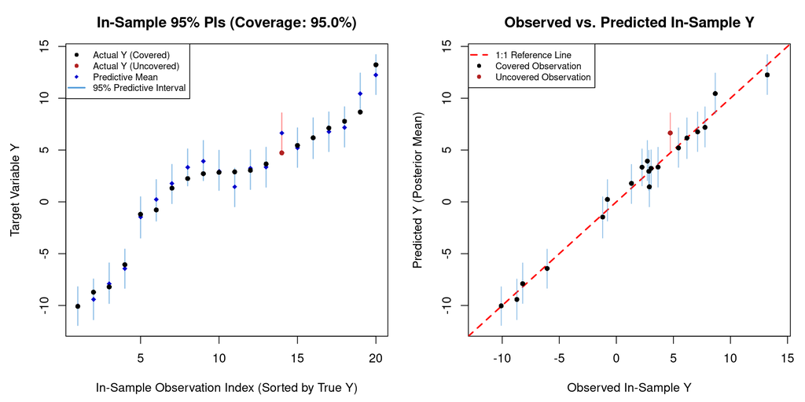

```r
# Define color schemes for covered vs uncovered observations
pt_cols  <- ifelse(covered, "black", "firebrick")
bar_cols <- ifelse(covered, rgb(0.3, 0.6, 0.85, 0.6), rgb(1, 0.4, 0.4, 0.7))

par(mfrow = c(1, 2), mar = c(4.5, 4.5, 3, 1))

# Plot 1: Ordered 95% PIs vs True In-Sample Y
sort_idx     <- order(Y_true)
Y_true_sort  <- Y_true[sort_idx]
pred_sort    <- pred_mean[sort_idx]
lower_sort   <- PI_lower[sort_idx]
upper_sort   <- PI_upper[sort_idx]
pt_cols_sort <- pt_cols[sort_idx]
bar_cols_sort<- bar_cols[sort_idx]

y_lims <- range(c(lower_sort, upper_sort, Y_true_sort))

plot(1:length(Y_true), Y_true_sort, type = "n", ylim = y_lims,
     xlab = "In-Sample Observation Index (Sorted by True Y)",
     ylab = "Target Variable Y",
     main = sprintf("In-Sample 95%% PIs (Coverage: %.1f%%)", coverage_prob * 100))

segments(x0 = 1:length(Y_true), y0 = lower_sort,
         x1 = 1:length(Y_true), y1 = upper_sort,
         col = bar_cols_sort, lwd = 1.5)
points(1:length(Y_true), pred_sort, pch = 18, col = "mediumblue", cex = 0.9)
points(1:length(Y_true), Y_true_sort, pch = 16, col = pt_cols_sort, cex = 0.9)

legend("topleft",
       legend = c("Actual Y (Covered)", "Actual Y (Uncovered)", "Predictive Mean", "95% Predictive Interval"),
       col = c("black", "firebrick", "mediumblue", rgb(0.3, 0.6, 0.85)),
       pch = c(16, 16, 18, NA), lty = c(NA, NA, NA, 1), lwd = c(NA, NA, NA, 2),
       bty = "o", bg = "white", cex = 0.75)

# Plot 2: Observed vs. Predicted Scatter
plot(Y_true, pred_mean, type = "n", ylim = y_lims, xlim = y_lims,
     xlab = "Observed In-Sample Y",
     ylab = "Predicted Y (Posterior Mean)",
     main = "Observed vs. Predicted In-Sample Y")

abline(0, 1, col = "red", lty = 2, lwd = 2)

segments(x0 = Y_true, y0 = PI_lower,
         x1 = Y_true, y1 = PI_upper,
         col = bar_cols, lwd = 1.2)
points(Y_true, pred_mean, pch = 16, col = pt_cols, cex = 0.9)

legend("topleft",
       legend = c("1:1 Reference Line", "Covered Observation", "Uncovered Observation"),
       col = c("red", "black", "firebrick"),
       lty = c(2, NA, NA), pch = c(NA, 16, 16), lwd = c(2, NA, NA),
       bty = "o", bg = "white", cex = 0.75)
```

```r
par(mfrow = c(1, 1))
```

# 3 Out-of-Sample Posterior Predictive Inference

## 3.1 Out-of-Sample Composition Sampling

# 4 Data Ingestion & Train / Test Partitioning

```r
# Load raw design and response data
X_raw <- as.matrix(read.table("../data/X.txt"))
Y     <- as.matrix(read.table("../data/Y.txt"))

set.seed(42)

# Define 20% hold-out proportion
n_total <- nrow(X_raw)
m <- floor(0.20 * n_total)

# Partition indices
test_idx  <- sample(1:n_total, size = m)
train_idx <- setdiff(1:n_total, test_idx)

# Training Set (Used exclusively for model estimation)
X_train <- cbind(1, X_raw[train_idx, , drop = FALSE])
Y_train <- Y[train_idx, , drop = FALSE]

# Held-out Test Set (Used exclusively for validation)
X_test  <- cbind(1, X_raw[test_idx, , drop = FALSE]) # X_tilde
Y_test  <- Y[test_idx, , drop = FALSE]                # Actual held-out targets
```

# 5 Inversion-Free Posterior Estimation

```r
library(mniw)

# 1. Training dimensions
n_tr   <- nrow(X_train)
p_cols <- ncol(X_train)
q_cols <- ncol(Y_train)

# 2. BLAS-optimized OLS Statistics via Cholesky decomposition
R_X <- chol(crossprod(X_train))
XtY <- crossprod(X_train, Y_train)

# Compute B_hat = (X^T X)^{-1} X^T Y using forward/backward substitution
B_hat <- backsolve(R_X, backsolve(R_X, XtY, transpose = TRUE))

# Compute Residual Sum of Squares (E^T E) using crossprod
E_residuals <- Y_train - X_train %*% B_hat
S_residuals <- crossprod(E_residuals)

# 3. Conjugate Posterior Hyperparameters
Psi_post <- S_residuals
nu_post  <- n_tr - p_cols
N_draws  <- 2000

# 4. Draw Inverse-Wishart covariance matrices using mniw::riwish
set.seed(123)
sigma_samples <- riwish(N_draws, Psi = Psi_post, nu = nu_post)

# 5. Draw Beta parameters using functional vectorization (lapply)
beta_list <- lapply(1:N_draws, function(i) {
  Sigma_i <- sigma_samples[, , i]
  U_Sigma <- chol(Sigma_i)
  Z       <- matrix(rnorm(p_cols * q_cols), nrow = p_cols, ncol = q_cols)

  return(B_hat + backsolve(R_X, Z) %*% U_Sigma)
})

# Collapse list into a (p x q x N_draws) array
beta_samples <- simplify2array(beta_list)
```

# 6 Out-of-Sample Predictive Composition Samplers

## 6.1 Custom Sampler

```r
set.seed(123)

Y_tilde_custom_list <- lapply(1:N_draws, function(i) {
  B_i     <- beta_samples[, , i]
  Sigma_i <- sigma_samples[, , i]

  M_i     <- X_test %*% B_i
  Z       <- matrix(rnorm(m * q_cols), nrow = m, ncol = q_cols)
  U_Sigma <- chol(Sigma_i)

  return(M_i + Z %*% U_Sigma)
})

Y_tilde_custom <- simplify2array(Y_tilde_custom_list)
```

## 6.2 Verification with `mniw::rMNorm`

```r
set.seed(123)

Y_tilde_mniw_list <- lapply(1:N_draws, function(i) {
  B_i     <- beta_samples[, , i]
  Sigma_i <- sigma_samples[, , i]

  M_i <- X_test %*% B_i
  return(drop(rMNorm(n = 1, Lambda = M_i, SigmaR = diag(m), SigmaC = Sigma_i)))
})

Y_tilde_mniw <- simplify2array(Y_tilde_mniw_list)
```

# 7 Out-of-Sample Diagnostics & Coverage Validation

```r
# Extract predictions for primary outcome Y[,1]
Y_tilde <- Y_tilde_custom[, 1, ] # Dimension: (m x N_draws)
Y_true  <- Y_test[, 1]

# Posterior predictive summary metrics
pred_mean <- rowMeans(Y_tilde)
PI_lower  <- apply(Y_tilde, 1, quantile, probs = 0.025)
PI_upper  <- apply(Y_tilde, 1, quantile, probs = 0.975)

# Calculate empirical out-of-sample coverage
covered <- (Y_true >= PI_lower) & (Y_true <= PI_upper)
coverage_prob <- mean(covered)

cat(sprintf("**Empirical Out-of-Sample 95%% Coverage:** %.2f%% (%d / %d test points covered)\n",
            coverage_prob * 100, sum(covered), m))
```

```
## **Empirical Out-of-Sample 95% Coverage:** 95.83% (230 / 240 test points covered)
```

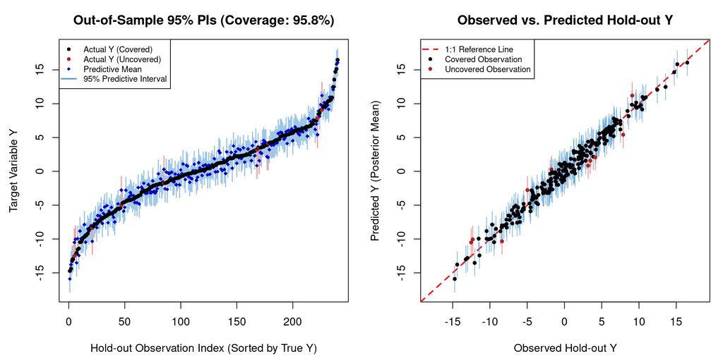

```r
# Styling setup
pt_cols  <- ifelse(covered, "black", "firebrick")
bar_cols <- ifelse(covered, rgb(0.3, 0.6, 0.85, 0.6), rgb(1, 0.4, 0.4, 0.7))

par(mfrow = c(1, 2), mar = c(4.5, 4.5, 3, 1))

# --- Plot 1: Ordered 95% PIs vs True Hold-out Y ---
sort_idx    <- order(Y_true)
Y_true_sort <- Y_true[sort_idx]
pred_sort   <- pred_mean[sort_idx]
lower_sort  <- PI_lower[sort_idx]
upper_sort  <- PI_upper[sort_idx]
pt_sort     <- pt_cols[sort_idx]
bar_sort    <- bar_cols[sort_idx]

y_lims <- range(c(lower_sort, upper_sort, Y_true_sort))

plot(1:m, Y_true_sort, type = "n", ylim = y_lims,
     xlab = "Hold-out Observation Index (Sorted by True Y)", ylab = "Target Variable Y",
     main = sprintf("Out-of-Sample 95%% PIs (Coverage: %.1f%%)", coverage_prob * 100))

segments(x0 = 1:m, y0 = lower_sort, x1 = 1:m, y1 = upper_sort, col = bar_sort, lwd = 1.5)
points(1:m, pred_sort, pch = 18, col = "mediumblue", cex = 0.8)
points(1:m, Y_true_sort, pch = 16, col = pt_sort, cex = 0.8)

legend("topleft",
       legend = c("Actual Y (Covered)", "Actual Y (Uncovered)", "Predictive Mean", "95% Predictive Interval"),
       col = c("black", "firebrick", "mediumblue", rgb(0.3, 0.6, 0.85)),
       pch = c(16, 16, 18, NA), lty = c(NA, NA, NA, 1), lwd = c(NA, NA, NA, 2), bty = "o", bg = "white", cex = 0.75)

# --- Plot 2: Observed vs. Predicted Scatter ---
plot(Y_true, pred_mean, type = "n", ylim = y_lims, xlim = y_lims,
     xlab = "Observed Hold-out Y", ylab = "Predicted Y (Posterior Mean)",
     main = "Observed vs. Predicted Hold-out Y")

abline(0, 1, col = "red", lty = 2, lwd = 2)
segments(x0 = Y_true, y0 = PI_lower, x1 = Y_true, y1 = PI_upper, col = bar_cols, lwd = 1.2)
points(Y_true, pred_mean, pch = 16, col = pt_cols, cex = 0.8)

legend("topleft",
       legend = c("1:1 Reference Line", "Covered Observation", "Uncovered Observation"),
       col = c("red", "black", "firebrick"), lty = c(2, NA, NA), pch = c(NA, 16, 16), lwd = c(2, NA, NA),
       bty = "o", bg = "white", cex = 0.75)
```

```r
par(mfrow = c(1, 1))
```

# 8 Modular Prediction via `mniw_posterior_predictive`

```r
# Source updated helper functions
source("../src/mniwPosteriorPredictive.r")

# Generate posterior predictive draws via mniw_posterior_predictive
set.seed(123)
Y_tilde_mod_custom <- mniw_posterior_predictive(X_test, beta_samples, sigma_samples)

# Extract metrics for primary target variable Y[,1]
Y_pred_draws <- Y_tilde_mod_custom[, 1, ] # (m x N_draws)
Y_true       <- Y_test[, 1]

pred_mean <- rowMeans(Y_pred_draws)
PI_lower  <- apply(Y_pred_draws, 1, quantile, probs = 0.025)
PI_upper  <- apply(Y_pred_draws, 1, quantile, probs = 0.975)

covered       <- (Y_true >= PI_lower) & (Y_true <= PI_upper)
coverage_prob <- mean(covered)

# --- Summary Table of Test Set Predictions ---
summary_df <- data.frame(
  Test_Obs  = 1:m,
  True_Y    = round(Y_true, 3),
  Pred_Mean = round(pred_mean, 3),
  Lower_95  = round(PI_lower, 3),
  Upper_95  = round(PI_upper, 3),
  Covered   = covered
)

knitr::kable(head(summary_df, 10), caption = "First 10 Test Set Predictions (mniw_posterior_predictive)")
```

First 10 Test Set Predictions (mniw_posterior_predictive)

| Test_Obs | True_Y | Pred_Mean | Lower_95 | Upper_95 | Covered |
| --- | --- | --- | --- | --- | --- |
| 1 | -6.248 | -6.286 | -8.193 | -4.295 | TRUE |
| 2 | -0.525 | -0.541 | -2.452 | 1.375 | TRUE |
| 3 | -11.517 | -9.944 | -11.914 | -8.085 | TRUE |
| 4 | -1.288 | -0.291 | -2.207 | 1.720 | TRUE |
| 5 | 6.035 | 5.862 | 3.932 | 7.763 | TRUE |
| 6 | 5.984 | 6.584 | 4.686 | 8.487 | TRUE |
| 7 | 13.560 | 12.490 | 10.539 | 14.415 | TRUE |
| 8 | 5.309 | 5.352 | 3.352 | 7.223 | TRUE |
| 9 | 5.154 | 5.757 | 3.913 | 7.775 | TRUE |
| 10 | -12.515 | -10.511 | -12.478 | -8.500 | FALSE |

```r
cat(sprintf("\n**Empirical Out-of-Sample 95%% Coverage (`mniw_posterior_predictive`):** %.2f%% (%d / %d test points covered)\n",
            coverage_prob * 100, sum(covered), m))
```

```
##
## **Empirical Out-of-Sample 95% Coverage (`mniw_posterior_predictive`):** 95.83% (230 / 240 test points covered)
```

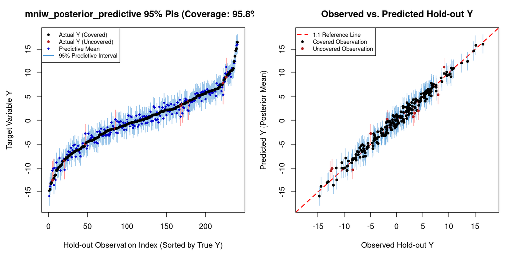

```r
# --- Diagnostic Plotting ---
pt_cols  <- ifelse(covered, "black", "firebrick")
bar_cols <- ifelse(covered, rgb(0.3, 0.6, 0.85, 0.6), rgb(1, 0.4, 0.4, 0.7))

par(mfrow = c(1, 2), mar = c(4.5, 4.5, 3, 1))

# Plot 1: Ordered 95% PIs
sort_idx    <- order(Y_true)
Y_true_sort <- Y_true[sort_idx]
pred_sort   <- pred_mean[sort_idx]
lower_sort  <- PI_lower[sort_idx]
upper_sort  <- PI_upper[sort_idx]
pt_sort     <- pt_cols[sort_idx]
bar_sort    <- bar_cols[sort_idx]

y_lims <- range(c(lower_sort, upper_sort, Y_true_sort))

plot(1:m, Y_true_sort, type = "n", ylim = y_lims,
     xlab = "Hold-out Observation Index (Sorted by True Y)", ylab = "Target Variable Y",
     main = sprintf("mniw_posterior_predictive 95%% PIs (Coverage: %.1f%%)", coverage_prob * 100))

segments(x0 = 1:m, y0 = lower_sort, x1 = 1:m, y1 = upper_sort, col = bar_sort, lwd = 1.5)
points(1:m, pred_sort, pch = 18, col = "mediumblue", cex = 0.8)
points(1:m, Y_true_sort, pch = 16, col = pt_sort, cex = 0.8)

legend("topleft",
       legend = c("Actual Y (Covered)", "Actual Y (Uncovered)", "Predictive Mean", "95% Predictive Interval"),
       col = c("black", "firebrick", "mediumblue", rgb(0.3, 0.6, 0.85)),
       pch = c(16, 16, 18, NA), lty = c(NA, NA, NA, 1), lwd = c(NA, NA, NA, 2), bty = "o", bg = "white", cex = 0.75)

# Plot 2: Observed vs. Predicted Scatter
plot(Y_true, pred_mean, type = "n", ylim = y_lims, xlim = y_lims,
     xlab = "Observed Hold-out Y", ylab = "Predicted Y (Posterior Mean)",
     main = "Observed vs. Predicted Hold-out Y")

abline(0, 1, col = "red", lty = 2, lwd = 2)
segments(x0 = Y_true, y0 = PI_lower, x1 = Y_true, y1 = PI_upper, col = bar_cols, lwd = 1.2)
points(Y_true, pred_mean, pch = 16, col = pt_cols, cex = 0.8)

legend("topleft",
       legend = c("1:1 Reference Line", "Covered Observation", "Uncovered Observation"),
       col = c("red", "black", "firebrick"), lty = c(2, NA, NA), pch = c(NA, 16, 16), lwd = c(2, NA, NA),
       bty = "o", bg = "white", cex = 0.75)
```

```r
par(mfrow = c(1, 1))
```

# 9 Modular Prediction via `mniw_posterior_predictive_pkg`

```r
# Generate posterior predictive draws via mniw_posterior_predictive_pkg
set.seed(123)
Y_tilde_mod_pkg <- mniw_posterior_predictive_pkg(X_test, beta_samples, sigma_samples)

# Extract metrics for primary target variable Y[,1]
Y_pred_draws_pkg <- Y_tilde_mod_pkg[, 1, ] # (m x N_draws)
Y_true           <- Y_test[, 1]

pred_mean_pkg <- rowMeans(Y_pred_draws_pkg)
PI_lower_pkg  <- apply(Y_pred_draws_pkg, 1, quantile, probs = 0.025)
PI_upper_pkg  <- apply(Y_pred_draws_pkg, 1, quantile, probs = 0.975)

covered_pkg       <- (Y_true >= PI_lower_pkg) & (Y_true <= PI_upper_pkg)
coverage_prob_pkg <- mean(covered_pkg)

# --- Summary Table of Test Set Predictions ---
summary_pkg_df <- data.frame(
  Test_Obs  = 1:m,
  True_Y    = round(Y_true, 3),
  Pred_Mean = round(pred_mean_pkg, 3),
  Lower_95  = round(PI_lower_pkg, 3),
  Upper_95  = round(PI_upper_pkg, 3),
  Covered   = covered_pkg
)

knitr::kable(head(summary_pkg_df, 10), caption = "First 10 Test Set Predictions (mniw_posterior_predictive_pkg)")
```

First 10 Test Set Predictions (mniw_posterior_predictive_pkg)

| Test_Obs | True_Y | Pred_Mean | Lower_95 | Upper_95 | Covered |
| --- | --- | --- | --- | --- | --- |
| 1 | -6.248 | -6.286 | -8.193 | -4.295 | TRUE |
| 2 | -0.525 | -0.606 | -2.512 | 1.401 | TRUE |
| 3 | -11.517 | -9.953 | -11.893 | -8.040 | TRUE |
| 4 | -1.288 | -0.264 | -2.259 | 1.725 | TRUE |
| 5 | 6.035 | 5.871 | 3.897 | 7.809 | TRUE |
| 6 | 5.984 | 6.553 | 4.538 | 8.562 | TRUE |
| 7 | 13.560 | 12.503 | 10.640 | 14.398 | TRUE |
| 8 | 5.309 | 5.325 | 3.372 | 7.214 | TRUE |
| 9 | 5.154 | 5.736 | 3.860 | 7.717 | TRUE |
| 10 | -12.515 | -10.510 | -12.405 | -8.640 | FALSE |

```r
cat(sprintf("\n**Empirical Out-of-Sample 95%% Coverage (`mniw_posterior_predictive_pkg`):** %.2f%% (%d / %d test points covered)\n",
            coverage_prob_pkg * 100, sum(covered_pkg), m))
```

```
##
## **Empirical Out-of-Sample 95% Coverage (`mniw_posterior_predictive_pkg`):** 96.67% (232 / 240 test points covered)
```

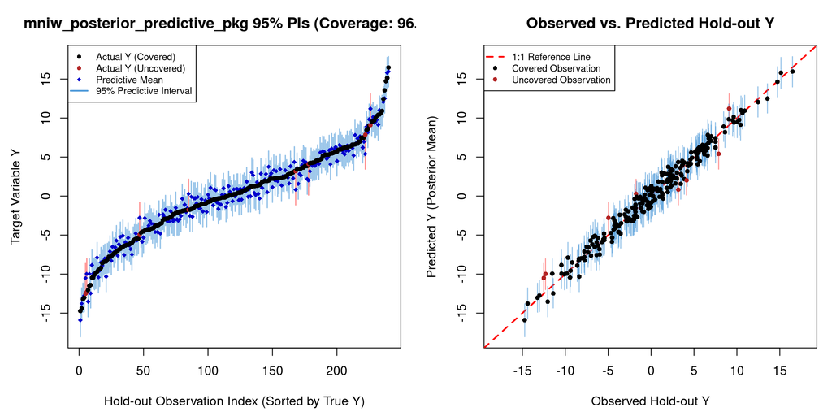

```r
# --- Diagnostic Plotting ---
pt_cols  <- ifelse(covered_pkg, "black", "firebrick")
bar_cols <- ifelse(covered_pkg, rgb(0.3, 0.6, 0.85, 0.6), rgb(1, 0.4, 0.4, 0.7))

par(mfrow = c(1, 2), mar = c(4.5, 4.5, 3, 1))

# Plot 1: Ordered 95% PIs
sort_idx    <- order(Y_true)
Y_true_sort <- Y_true[sort_idx]
pred_sort   <- pred_mean_pkg[sort_idx]
lower_sort  <- PI_lower_pkg[sort_idx]
upper_sort  <- PI_upper_pkg[sort_idx]
pt_sort     <- pt_cols[sort_idx]
bar_sort    <- bar_cols[sort_idx]

y_lims <- range(c(lower_sort, upper_sort, Y_true_sort))

plot(1:m, Y_true_sort, type = "n", ylim = y_lims,
     xlab = "Hold-out Observation Index (Sorted by True Y)", ylab = "Target Variable Y",
     main = sprintf("mniw_posterior_predictive_pkg 95%% PIs (Coverage: %.1f%%)", coverage_prob_pkg * 100))

segments(x0 = 1:m, y0 = lower_sort, x1 = 1:m, y1 = upper_sort, col = bar_sort, lwd = 1.5)
points(1:m, pred_sort, pch = 18, col = "mediumblue", cex = 0.8)
points(1:m, Y_true_sort, pch = 16, col = pt_sort, cex = 0.8)

legend("topleft",
       legend = c("Actual Y (Covered)", "Actual Y (Uncovered)", "Predictive Mean", "95% Predictive Interval"),
       col = c("black", "firebrick", "mediumblue", rgb(0.3, 0.6, 0.85)),
       pch = c(16, 16, 18, NA), lty = c(NA, NA, NA, 1), lwd = c(NA, NA, NA, 2), bty = "o", bg = "white", cex = 0.75)

# Plot 2: Observed vs. Predicted Scatter
plot(Y_true, pred_mean_pkg, type = "n", ylim = y_lims, xlim = y_lims,
     xlab = "Observed Hold-out Y", ylab = "Predicted Y (Posterior Mean)",
     main = "Observed vs. Predicted Hold-out Y")

abline(0, 1, col = "red", lty = 2, lwd = 2)
segments(x0 = Y_true, y0 = PI_lower_pkg, x1 = Y_true, y1 = PI_upper_pkg, col = bar_cols, lwd = 1.2)
points(Y_true, pred_mean_pkg, pch = 16, col = pt_cols, cex = 0.8)

legend("topleft",
       legend = c("1:1 Reference Line", "Covered Observation", "Uncovered Observation"),
       col = c("red", "black", "firebrick"), lty = c(2, NA, NA), pch = c(NA, 16, 16), lwd = c(2, NA, NA),
       bty = "o", bg = "white", cex = 0.75)
```

```r
par(mfrow = c(1, 1))
```

# 10 Appendix: Calculus-Free Derivation of Posterior Predictive Matrix-t Density via Bayes’ Identity

This appendix presents a calculus-free derivation of the exact posterior predictive density $p(\tilde{Y} \mid D, \tilde{X})$ using **Bayes’ identity** evaluated at a specific point.

## 10.1 Framing via Bayes’ Identity

By Bayes’ theorem, the posterior predictive density satisfies the following relationship for any parameter choice $(\beta, \Sigma)$:

$$p(\tilde{Y} \mid D, \tilde{X}) =
\frac{p(\tilde{Y} \mid \beta, \Sigma, \tilde{X}) \, p(\beta, \Sigma \mid
D)}{p(\beta, \Sigma \mid D, \tilde{Y}, \tilde{X})}$$

The numerator is completely specified from our model setup: * **Conditional Likelihood:** $p(\tilde{Y} \mid \beta, \Sigma, \tilde{X}) = \mathcal{MN}_{\tilde{m} \times p}(\tilde{Y} \mid \tilde{X}\beta, \Omega, \Sigma)$ * **Training Posterior:** $p(\beta, \Sigma \mid D) = \mathcal{MN}_{k \times p}(\beta \mid M_n m_n, M_n, \Sigma) \times \mathcal{IW}_p(\Sigma \mid \nu_n, \Psi_n)$

where the training dataset parameters $D = (Y, X)$ are:

$$\begin{aligned}
M_n^{-1} &= M_0^{-1} + X^\top X \\
m_n &= X^\top Y + m_0 \\
\nu_n &= \nu_0 + n \\
\Psi_n &= S_0 + Y^\top Y + m_0^\top M_0 m_0 - m_n^\top M_n m_n
\end{aligned}$$

Because the numerator is known, evaluating $p(\tilde{Y} \mid D, \tilde{X})$ reduces to deriving the explicit form of the denominator $p(\beta, \Sigma \mid D, \tilde{Y}, \tilde{X})$ as an augmented MNIW density and simplifying the resulting matrix determinants.

## 10.2 Deriving the Denominator (Augmented MNIW Posterior)

To derive the explicit form of $p(\beta, \Sigma \mid D, \tilde{Y}, \tilde{X})$, we treat the training posterior $p(\beta, \Sigma \mid D)$ as a prior distribution and update it with the new target observation likelihood $p(\tilde{Y} \mid \beta, \Sigma, \tilde{X})$.

### 10.2.1 Step 1: The Augmented Linear Model Setup

The new target observations follow the matrix linear regression model:

$$\tilde{Y} = \tilde{X}\beta + \tilde{E},
\quad \tilde{E} \sim \mathcal{MN}_{\tilde{m} \times p}(0, \Omega,
\Sigma)$$

Combining the target observation likelihood with our existing training posterior yields:

$$p(\beta, \Sigma \mid D, \tilde{Y},
\tilde{X}) \propto p(\tilde{Y} \mid \beta, \Sigma, \tilde{X}) \,
p(\beta, \Sigma \mid D)$$

Substituting the Matrix-Normal and Inverse-Wishart densities:

$$\begin{aligned}
p(\beta, \Sigma \mid D, \tilde{Y}, \tilde{X}) &\propto
|\Omega|^{-\frac{p}{2}} |\Sigma|^{-\frac{\tilde{m}}{2}} \exp\left(
-\frac{1}{2} \text{tr}\left[ \Sigma^{-1} (\tilde{Y} -
\tilde{X}\beta)^\top \Omega^{-1} (\tilde{Y} - \tilde{X}\beta) \right]
\right) \\
&\quad \times |M_n|^{-\frac{p}{2}} |\Sigma|^{-\frac{k}{2}}
\exp\left( -\frac{1}{2} \text{tr}\left[ \Sigma^{-1} (\beta - M_n
m_n)^\top M_n^{-1} (\beta - M_n m_n) \right] \right) \\
&\quad \times |\Psi_n|^{\frac{\nu_n}{2}} |\Sigma|^{-\frac{\nu_n + p
+ 1}{2}} \exp\left( -\frac{1}{2} \text{tr}\left[ \Sigma^{-1} \Psi_n
\right] \right)
\end{aligned}$$

Grouping powers of $|\Sigma|$ and combining all quadratic terms inside the trace function gives:

$$p(\beta, \Sigma \mid D, \tilde{Y},
\tilde{X}) \propto |\Sigma|^{-\frac{(\nu_n + \tilde{m}) + k + p + 1}{2}}
\exp\left( -\frac{1}{2} \text{tr}\left[ \Sigma^{-1} Q(\beta) \right]
\right)$$

where the total quadratic matrix $Q(\beta)$ is:

$$Q(\beta) = (\beta - M_n m_n)^\top
M_n^{-1} (\beta - M_n m_n) + (\tilde{Y} - \tilde{X}\beta)^\top
\Omega^{-1} (\tilde{Y} - \tilde{X}\beta) + \Psi_n$$

### 10.2.2 Step 2: Completing the Square in $\beta$

To put $Q(\beta)$ into a recognizable Matrix-Normal quadratic form, we expand the terms containing $\beta$:

$$\begin{aligned}
Q(\beta) &= \beta^\top M_n^{-1} \beta - \beta^\top m_n - m_n^\top
\beta + m_n^\top M_n m_n \\
&\quad + \beta^\top \tilde{X}^\top \Omega^{-1} \tilde{X} \beta -
\beta^\top \tilde{X}^\top \Omega^{-1} \tilde{Y} - \tilde{Y}^\top
\Omega^{-1} \tilde{X} \beta + \tilde{Y}^\top \Omega^{-1} \tilde{Y} +
\Psi_n
\end{aligned}$$

Grouping the quadratic ($\beta^\top \cdot \beta$) and linear ($\beta^\top \cdot$) terms:

$$Q(\beta) = \beta^\top \underbrace{\left(
M_n^{-1} + \tilde{X}^\top \Omega^{-1} \tilde{X} \right)}_{M_n^{*-1}}
\beta - \beta^\top \underbrace{\left( m_n + \tilde{X}^\top \Omega^{-1}
\tilde{Y} \right)}_{m_n^*} - \underbrace{\left( m_n + \tilde{X}^\top
\Omega^{-1} \tilde{Y} \right)^\top}_{(m_n^*)^\top} \beta +
C$$

where $C = m_n^\top M_n m_n + \tilde{Y}^\top \Omega^{-1} \tilde{Y} + \Psi_n$ collects all terms independent of $\beta$.

Completing the square with respect to $M_n^{*-1}$ and $m_n^*$:

$$Q(\beta) = (\beta - M_n^* m_n^*)^\top
M_n^{*-1} (\beta - M_n^* m_n^*) + \Psi_n^*$$

where the updated precision and mean parameters are:

$$\begin{aligned}
M_n^{*-1} &= M_n^{-1} + \tilde{X}^\top \Omega^{-1} \tilde{X} \\
m_n^* &= m_n + \tilde{X}^\top \Omega^{-1} \tilde{Y}
\end{aligned}$$

### 10.2.3 Step 3: Simplifying the Updated Scale Matrix $\Psi_n^*$

The leftover term $\Psi_n^*$ collects all residual quadratic terms:

$$\Psi_n^* = \Psi_n + m_n^\top M_n m_n +
\tilde{Y}^\top \Omega^{-1} \tilde{Y} - (m_n^*)^\top M_n^*
m_n^*$$

Substituting $m_n^* = m_n + \tilde{X}^\top \Omega^{-1} \tilde{Y}$ and $M_n^* = (M_n^{-1} + \tilde{X}^\top \Omega^{-1} \tilde{X})^{-1}$:

$$\Psi_n^* = \Psi_n + \tilde{Y}^\top
\Omega^{-1} \tilde{Y} + m_n^\top M_n m_n - (m_n + \tilde{X}^\top
\Omega^{-1} \tilde{Y})^\top (M_n^{-1} + \tilde{X}^\top \Omega^{-1}
\tilde{X})^{-1} (m_n + \tilde{X}^\top \Omega^{-1}
\tilde{Y})$$

Applying the Woodbury matrix identity to $(M_n^{-1} + \tilde{X}^\top \Omega^{-1} \tilde{X})^{-1}$:

$$(M_n^{-1} + \tilde{X}^\top \Omega^{-1}
\tilde{X})^{-1} = M_n - M_n \tilde{X}^\top (\Omega + \tilde{X} M_n
\tilde{X}^\top)^{-1} \tilde{X} M_n$$

Expanding and cancelling cross-terms yields the predictive residual form:

$$\Psi_n^* = \Psi_n + (\tilde{Y} -
\tilde{X} M_n m_n)^\top (\Omega + \tilde{X} M_n \tilde{X}^\top)^{-1}
(\tilde{Y} - \tilde{X} M_n m_n)$$

### 10.2.4 Step 4: Summary of Denominator Parameters

The augmented posterior $p(\beta, \Sigma \mid D, \tilde{Y}, \tilde{X})$ is an MNIW distribution:

$$p(\beta, \Sigma \mid D, \tilde{Y},
\tilde{X}) = \mathcal{MN}_{k \times p}(\beta \mid M_n^* m_n^*, M_n^*,
\Sigma) \times \mathcal{IW}_p(\Sigma \mid \nu_n^*,
\Psi_n^*)$$

with augmented parameters:

$$\begin{aligned}
M_n^{*-1} &= M_n^{-1} + \tilde{X}^\top \Omega^{-1} \tilde{X} \\
m_n^* &= m_n + \tilde{X}^\top \Omega^{-1} \tilde{Y} \\
\nu_n^* &= \nu_n + \tilde{m} \\
\Psi_n^* &= \Psi_n + (\tilde{Y} - \tilde{X} M_n m_n)^\top (\Omega +
\tilde{X} M_n \tilde{X}^\top)^{-1} (\tilde{Y} - \tilde{X} M_n m_n)
\end{aligned}$$

## 10.3 Ratio Evaluation and Term Cancellations

Because Bayes’ identity holds for any valid parameters $(\beta, \Sigma)$, we can evaluate the density ratio at any convenient point. Evaluating at the augmented posterior mean $\beta = M_n^* m_n^*$ simplifies the algebra dramatically, as the quadratic parameter term $(\beta - M_n^* m_n^*)$ vanishes to zero.

### 10.3.1 Step 1: The Full Ratio with Visual Cancellations

Substituting the full probability densities of the conditional likelihood, training posterior, and augmented posterior into Bayes’ identity at $\beta = M_n^* m_n^*$ gives:

$$\require{cancel}
p(\tilde{Y} \mid D, \tilde{X}) = \frac{
\overbrace{\left( (2\pi)^{-\frac{\tilde{m}p}{2}}
|\Omega|^{-\frac{p}{2}} |\Sigma|^{-\frac{\tilde{m}}{2}}
\right)}^{\text{Likelihood Norm.}}
\overbrace{\left( \cancel{(2\pi)^{-\frac{kp}{2}}} |M_n|^{-\frac{p}{2}}
\cancel{|\Sigma|^{-\frac{k}{2}}} \cdot
\frac{|\Psi_n|^{\frac{\nu_n}{2}}}{\cancel{2^{\frac{\nu_n p}{2}}}
\Gamma_p\left(\frac{\nu_n}{2}\right)} \cancel{|\Sigma|^{-\frac{\nu_n + p
+ 1}{2}}} \right)}^{\text{Training Posterior Norm.}}
\overbrace{\cancel{\exp\left( -\frac{1}{2} \text{tr}\left[ \Sigma^{-1}
\Psi_n^* \right] \right)}}^{\text{Combined Exponential Kernel}}
}{
\underbrace{\left( \cancel{(2\pi)^{-\frac{kp}{2}}}
|M_n^*|^{-\frac{p}{2}} \cancel{|\Sigma|^{-\frac{k}{2}}}
\right)}_{\text{Augmented Matrix-Normal Norm.}}
\underbrace{\left( \frac{|\Psi_n^*|^{\frac{\nu_n +
\tilde{m}}{2}}}{\cancel{2^{\frac{\nu_n p}{2}}} 2^{\frac{\tilde{m}p}{2}}
\Gamma_p\left(\frac{\nu_n + \tilde{m}}{2}\right)}
\cancel{|\Sigma|^{-\frac{\nu_n + \tilde{m} + p + 1}{2}}}
\right)}_{\text{Augmented Inverse-Wishart Norm.}}
\underbrace{\cancel{\exp\left( -\frac{1}{2} \text{tr}\left[
\Sigma^{-1} \Psi_n^* \right] \right)}}_{\text{Augmented Exponential
Kernel}}
}$$

### 10.3.2 Step 2: Why Terms Cancel Out

1. **Exponential Kernel Cancellation:**
   - At $\beta = M_n^* m_n^*$, the Matrix-Normal exponent in the denominator becomes $\exp\left( -\frac{1}{2} \text{tr}[\Sigma^{-1} (0)] \right) = 1$.
   - In the numerator, adding the quadratic exponents from the likelihood and training prior yields $\exp\left( -\frac{1}{2} \text{tr}\left[ \Sigma^{-1} \Psi_n^* \right] \right)$.
   - This identically matches the Inverse-Wishart exponential term in the denominator, so all exponents cancel completely.
2. **Parameter $\Sigma$ Power Cancellation:**
   - **Numerator Exponent:** $-\frac{\tilde{m}}{2} - \frac{k}{2} - \frac{\nu_n + p + 1}{2} = -\frac{\nu_n + \tilde{m} + k + p + 1}{2}$
   - **Denominator Exponent:** $-\frac{k}{2} - \frac{\nu_n^* + p + 1}{2} = -\frac{k}{2} - \frac{(\nu_n + \tilde{m}) + p + 1}{2} = -\frac{\nu_n + \tilde{m} + k + p + 1}{2}$
   - The powers of $|\Sigma|$ are identical in both numerator and denominator, so $\Sigma$ drops out entirely without requiring integration.
3. **Constant Scalar Simplification:** Combining the remaining powers of $2$, $\pi$, and multivariate gamma functions leaves:

   $$\frac{(2\pi)^{-\frac{\tilde{m}p}{2}}}{2^{-\frac{\tilde{m}p}{2}}}
   \cdot \frac{\Gamma_p\left(\frac{\nu_n +
   \tilde{m}}{2}\right)}{\Gamma_p\left(\frac{\nu_n}{2}\right)} =
   \frac{\Gamma_p\left(\frac{\nu_n +
   \tilde{m}}{2}\right)}{\Gamma_p\left(\frac{\nu_n}{2}\right)
   \pi^{\tilde{m}p/2}}$$

### 10.3.3 Step 3: Row Scale Determinant Simplification & Determinant Identities

After scalar and exponential cancellations, the remaining determinant ratio involving $M_n$ and $M_n^*$ is:

$$\frac{|M_n^*|^{\frac{p}{2}}}{|M_n|^{\frac{p}{2}}
|\Omega|^{\frac{p}{2}}} = \left( \frac{|M_n^*|}{|M_n| |\Omega|}
\right)^{\frac{p}{2}}$$

To simplify $\frac{|M_n^*|}{|M_n| |\Omega|}$, we invert the matrices to work with precision terms:

$$\frac{|M_n^*|}{|M_n| |\Omega|} =
\frac{1}{|M_n^{*-1}| \cdot |M_n| \cdot |\Omega|} = \frac{1}{\left| M_n
\left( M_n^{-1} + \tilde{X}^\top \Omega^{-1} \tilde{X} \right) \right|
\cdot |\Omega|} = \frac{1}{\left| I_k + M_n \tilde{X}^\top \Omega^{-1}
\tilde{X} \right| \cdot |\Omega|}$$

#### 10.3.3.1 Quick Derivation: Sylvester’s Determinant Identity

To swap the dimensions inside the determinant from $k \times k$ to $\tilde{m} \times \tilde{m}$, we use **Sylvester’s Determinant Identity**: $|I_k + A B| = |I_{\tilde{m}} + B A|$.

*Proof:* Consider the block matrix $M$:

$$M = \begin{pmatrix} I_k & -A \\ B
& I_{\tilde{m}} \end{pmatrix}$$

We compute $\det(M)$ in two different ways using block row elimination:

1. **Forward Elimination (isolating $I_k + AB$):**  
   Multiply $M$ on the left by the block matrix $\begin{pmatrix} I_k & A \\ 0 & I_{\tilde{m}} \end{pmatrix}$:

   $$\begin{pmatrix} I_k & A \\ 0 &
   I_{\tilde{m}} \end{pmatrix} \begin{pmatrix} I_k & -A \\ B &
   I_{\tilde{m}} \end{pmatrix} = \begin{pmatrix} I_k + AB & 0 \\ B
   & I_{\tilde{m}} \end{pmatrix}$$

   Taking determinants on both sides (noting that upper/lower triangular block matrices have determinants equal to the product of their diagonal blocks):

   $$\underbrace{\det \begin{pmatrix} I_k
   & A \\ 0 & I_{\tilde{m}} \end{pmatrix}}_{1} \cdot \det(M) = \det
   \begin{pmatrix} I_k + AB & 0 \\ B & I_{\tilde{m}} \end{pmatrix}
   \implies \det(M) = |I_k + AB|$$
2. **Reverse Elimination (isolating $I_{\tilde{m}} + BA$):**  
   Multiply $M$ on the left by the block matrix $\begin{pmatrix} I_k & 0 \\ -B & I_{\tilde{m}} \end{pmatrix}$:

   $$\begin{pmatrix} I_k & 0 \\ -B &
   I_{\tilde{m}} \end{pmatrix} \begin{pmatrix} I_k & -A \\ B &
   I_{\tilde{m}} \end{pmatrix} = \begin{pmatrix} I_k & -A \\ 0 &
   I_{\tilde{m}} + BA \end{pmatrix}$$

   Taking determinants on both sides:

   $$\underbrace{\det \begin{pmatrix} I_k
   & 0 \\ -B & I_{\tilde{m}} \end{pmatrix}}_{1} \cdot \det(M) =
   \det \begin{pmatrix} I_k & -A \\ 0 & I_{\tilde{m}} + BA
   \end{pmatrix} \implies \det(M) = |I_{\tilde{m}} + BA|$$

Equating both expressions for $\det(M)$ gives Sylvester’s identity:

$$|I_k + AB| = |I_{\tilde{m}} +
BA|$$

#### 10.3.3.2 Application to Row Scale Determinants

Applying Sylvester’s identity with $A = M_n \tilde{X}^\top$ and $B = \Omega^{-1} \tilde{X}$:

$$\left| I_k + M_n \tilde{X}^\top
\Omega^{-1} \tilde{X} \right| = \left| I_{\tilde{m}} + \Omega^{-1}
\tilde{X} M_n \tilde{X}^\top \right| = \left| \Omega^{-1} \left( \Omega
+ \tilde{X} M_n \tilde{X}^\top \right) \right| = |\Omega|^{-1} \left|
\Omega + \tilde{X} M_n \tilde{X}^\top \right|$$

Substituting this back into our ratio:

$$\frac{|M_n^*|}{|M_n| |\Omega|} =
\frac{1}{|\Omega|^{-1} \left| \Omega + \tilde{X} M_n \tilde{X}^\top
\right| \cdot |\Omega|} = \left| \Omega + \tilde{X} M_n \tilde{X}^\top
\right|^{-1}$$

Raising this to the power of $p/2$ yields the exact row-covariance determinant of the Matrix Student-t distribution:

$$\frac{|M_n^*|^{\frac{p}{2}}}{|M_n|^{\frac{p}{2}}
|\Omega|^{\frac{p}{2}}} = \left| \Omega + \tilde{X} M_n \tilde{X}^\top
\right|^{-\frac{p}{2}}$$

### 10.3.4 Final Density Function

Combining all simplified components yields the closed-form posterior predictive density:

$$p(\tilde{Y} \mid D, \tilde{X}) =
\frac{\Gamma_p\left(\frac{\nu_n +
\tilde{m}}{2}\right)}{\Gamma_p\left(\frac{\nu_n}{2}\right)
\pi^{\tilde{m} p/2}} \left|\Omega + \tilde{X} M_n
\tilde{X}^\top\right|^{-p/2} |\Psi_n|^{-\tilde{m}/2} \left| I_p +
\Psi_n^{-1} (\tilde{Y} - \tilde{X} M_n m_n)^\top (\Omega + \tilde{X} M_n
\tilde{X}^\top)^{-1} (\tilde{Y} - \tilde{X} M_n m_n)
\right|^{-\frac{\nu_n + \tilde{m}}{2}}$$

This defines the Matrix Student-t predictive distribution:

$$\tilde{Y} \mid D, \tilde{X} \sim
\mathcal{MT}_{\tilde{m} \times p}\left( \tilde{X} M_n m_n, \; \Omega +
\tilde{X} M_n \tilde{X}^\top, \; \Psi_n, \; \nu_n \right)$$